# 19/05/2023

ARQUE Maxime

2023-05-19

```r
library(panstripe)
library(ape)
library(patchwork)
library(TreeTools)
library(ggtree)
library(castor)
library(ggplot2)
set.seed(1234)
```

## Sélection des 18 SAGs + génome de référence

```r
# SAGs : 496_N4_C1 / 521B10_C1 / 498P15_C1 / 529C4_C1 / 495K23_C1 / 498B22_C2 / 498C16_C2 / 529D18_C3 / 496A2_C3 / 529J15_C3 / 518A17_C3 / 495L20_C3 / 528N17_C4 / 498I20_C5 / 498A3_C8 / 527L22_C8 / 520K10_C9 / 528J8_C9 / P9312
```

###### **Je les ai récupérés à partir de la table des SAGs dans la thèse d’Hélène GARDON**

```r
phylo.file.name="/home/maarque/Applications/Fichiers/concat-core-genes.phy_phyml_tree_GTR+I+G.txt"
rtab.file.name="/home/maarque/Applications/Fichiers/matrice_binaire_equilibre.tab"
tree <- read.tree(phylo.file.name)
pa <- read_rtab(rtab.file.name)
```

## Extraction des 18 feuilles de l’arbre

```r
SAGs=c("496N4_C1","521B10_C1","498P15_C1","529C4_C1","495K23_C1","498B22_C2","498C16_C2","529D18_C3","496A2_C3","529J15_C3","518A17_C3","495L20_C3","528N17_C4","498I20_C5","498A3_C8","527L22_C8","520K10_C9","528J8_C9","P9312")

tree = KeepTip(tree, SAGs, preorder = TRUE)
pa=pa[SAGs,]
```

## Re-utilisation de panstripe sur le jeu de données réduit

```r
fit <- panstripe(pa, tree, family="quasipoisson")
```

###### **On a toujours le même problème si on utilise pas “quasipoisson” : Panstripe model fit failed! This can sometime be caused by unusual branch lengths**

## Plots du nouveau fit du jeu de données réduit

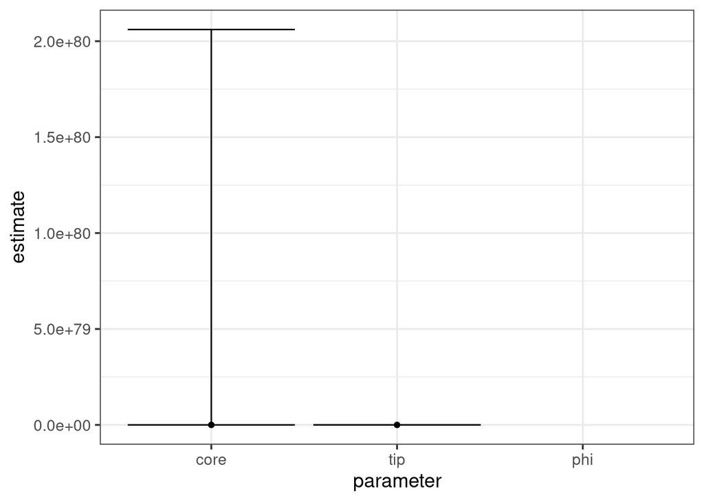

```r
plot_pangenome_params(fit)
```

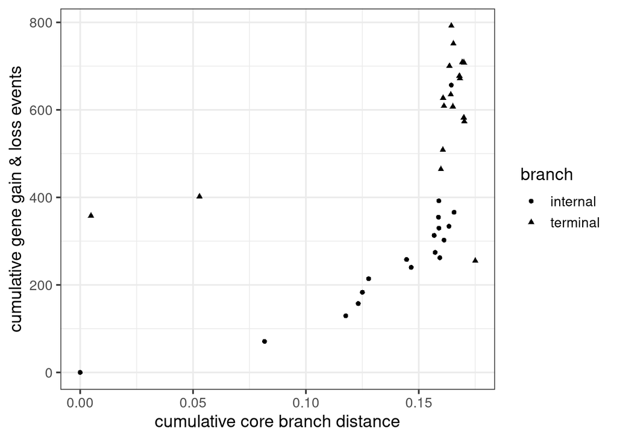

```r
plot_pangenome_cumulative(fit)
```

## Arbre de gain et pertes de gènes du nouveau jeu de données

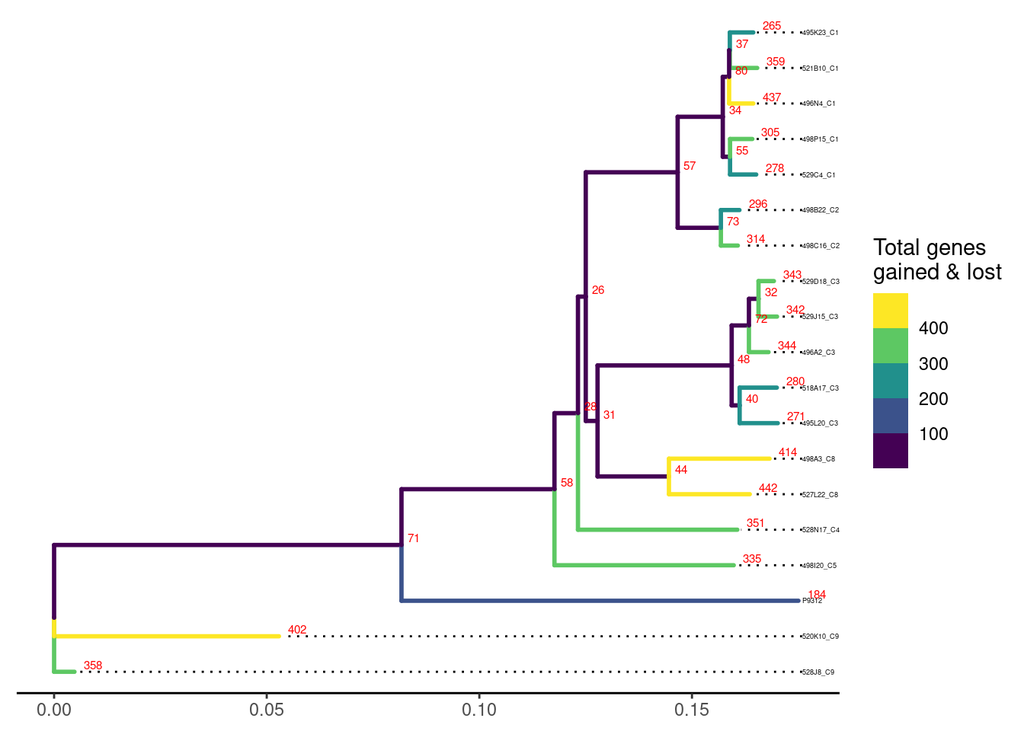

```r
gt <- dplyr::full_join(ggtree::fortify(fit$tree), data.frame(node = fit$tree$edge[,2], trait = fit$data$acc), by = "node")

data_x=gt$x
data_y=gt$y
data_labels=round(gt$trait)

#Arbre gain/perte qui affiche les gains/pertes de gènes
plot_gain_loss(fit,tip_label = FALSE)+geom_tiplab(align=TRUE,size=1.2,color="black")+
  geom_text(aes(data_x,data_y),label=data_labels, check_overlap = FALSE, color="red", size=2,hjust=-0.5,vjust=-0.3)
```

```r
#Créer le fichier de l'arbre au format newick
write_tree(tree, file = "/home/maarque/Applications/Fichiers/SAGs_reduits/SAGs_reduits.nwk", append = F)

#La matrice était pas dans le bon sens donc je l'ai tranposée
matrice_transpo=t(pa)

#Export de la matrice
write.table(matrice_transpo, file="/home/maarque/Applications/Fichiers/SAGs_reduits/Rmatrix.tab", row.names=TRUE, col.names=TRUE, sep="\t")
```

###### Les données de l’arbre (numéro de branche, nombre de gain/perte, branche tip/core) sont stockées dans “gt”

## Importation des données de count

###### **Je n’ai pas trouvé d’outil sur count pour importer les résultats en termes de gain/perte de gènes, donc j’ai sélectionné tous les COGs (avec ctrl + A) et dans la fenêtre de résultats j’ai copié/collé les valeurs de chacune des branches dans un fichier .csv**

```r
data_count=read.table("/home/maarque/Applications/Fichiers/SAGs_reduits/Matrix_data_count.tab",header = TRUE,sep="\t")

# Comme count nécéssitait de supprimer les "_", je les remets ici pour pouvoir comparer les deux data frames
data_count$Node=sub(" ","_",data_count$Node)

# Ajout d'une colonne total gain/loss au dataframe de count qui n'en a pas
data_count=cbind(data_count,data.frame(data_count$gain+data_count$loss))
colnames(data_count)[6]="total_gainloss"
```

## Ajout de lettres pour identification des branches non tip

###### **Elles n’ont pas de noms attribués et pour les comparer facilement je leurs attribue un nom : A,B,C…. car pas possible de les identifier par leurs lengths car y’a 11 lengths qui sont partagées par plusieurs branches. Je ne voyais pas comment faire autrement pour faire ça, donc je l’ai fait manuellement en regardant la correspondance des branches entre les deux programmes**

```r
#Attribution des lettres de chaques branches
gt$label[20:36]=c("A","B","C","D","E","F","G","H","I","J","K","L","M","N","O","P","Q")
data_count$Node[20:36]=c("G","J","I","K","H","F","M","O","Q","P","N","L","E","D","C","B","A")


#Changement du nom de colonne pour pouvoir merge sur la même colonne
colnames(data_count)[1]="label"
merged_df=merge.data.frame(gt,data_count,by="label")

#Suppression des colonnes inutiles, et changement de nom des colonnes
merged_df = subset(merged_df, select = -c(x,y,branch,angle,parent,node,branch.length,edge.length))
colnames(merged_df)=c("Label","IsTip","gainloss_PANSTRIPE","Number_of_COGS_at_node_COUNT","gain_COUNT","loss_COUNT","gainloss_COUNT")

#Changement de l'ordre des colonnes
merged_df=merged_df[ , c("Label","IsTip","gainloss_PANSTRIPE","gainloss_COUNT","gain_COUNT","loss_COUNT","Number_of_COGS_at_node_COUNT")]

#Arrondi des valeurs
merged_df$gainloss_PANSTRIPE=round(merged_df$gainloss_PANSTRIPE)
```

## Comparaison panstripe/count

```r
#Ajout de deux colonnes de comparaison du total gain/perte
merged_df=cbind(merged_df,round(merged_df$gainloss_PANSTRIPE/merged_df$gainloss_COUNT,2),100-round(merged_df$gainloss_PANSTRIPE*100/merged_df$gainloss_COUNT,2))
#Rename les colonnes
colnames(merged_df)[8:9]=c("panstripe/count","% _diff")

print(merged_df[c(1,3,4,8,9)])
```

```
##        Label gainloss_PANSTRIPE gainloss_COUNT panstripe/count % _diff
## 1  495K23_C1                265            252            1.05   -5.16
## 2  495L20_C3                271            305            0.89   11.15
## 3   496A2_C3                344            478            0.72   28.03
## 4   496N4_C1                437            586            0.75   25.43
## 5   498A3_C8                414            432            0.96    4.17
## 6  498B22_C2                296            305            0.97    2.95
## 7  498C16_C2                314            305            1.03   -2.95
## 8  498I20_C5                335            405            0.83   17.28
## 9  498P15_C1                305            366            0.83   16.67
## 10 518A17_C3                280            246            1.14  -13.82
## 11 520K10_C9                402            443            0.91    9.26
## 12 521B10_C1                359            372            0.97    3.49
## 13 527L22_C8                442            424            1.04   -4.25
## 14  528J8_C9                358            317            1.13  -12.93
```

[output cut: 22 more lines]

```r
#Calcul de la moyenne de la différence entre panstripe et count
moy_diff=mean(abs(merged_df$`% _diff`), na.rm = T)
print(moy_diff)
```

```
## [1] 32.25057
```

```r
#Calcul de la moyenne de la différence entre panstripe et count pour les branches TIP
print(mean(abs(merged_df$`% _diff`[merged_df$IsTip=="TRUE"]),na.rm=T))
```

```
## [1] 12.95632
```

```r
#Calcul de la moyenne de la différence entre panstripe et count pour les branches NON TIP
print(mean(abs(merged_df$`% _diff`[merged_df$IsTip=="FALSE"]),na.rm=T))
```

```
## [1] 55.1625
```

## Barplots des résultats

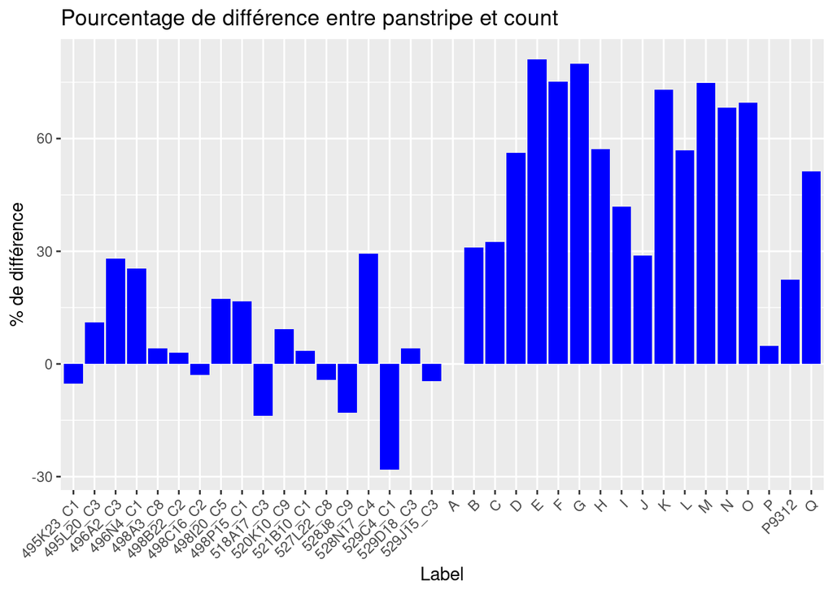

```r
# Barplot du % de différence
ggplot(merged_df, aes(x = Label, y=merged_df$`% _diff`)) +
    geom_bar(stat = "identity", position = "dodge", fill = "blue")+scale_fill_brewer(palette = "Set1")+theme(axis.text.x = element_text(angle = 45, vjust = 1, hjust=1))+ ggtitle("Pourcentage de différence entre panstripe et count")+labs(y = "% de différence", x = "Label")
```

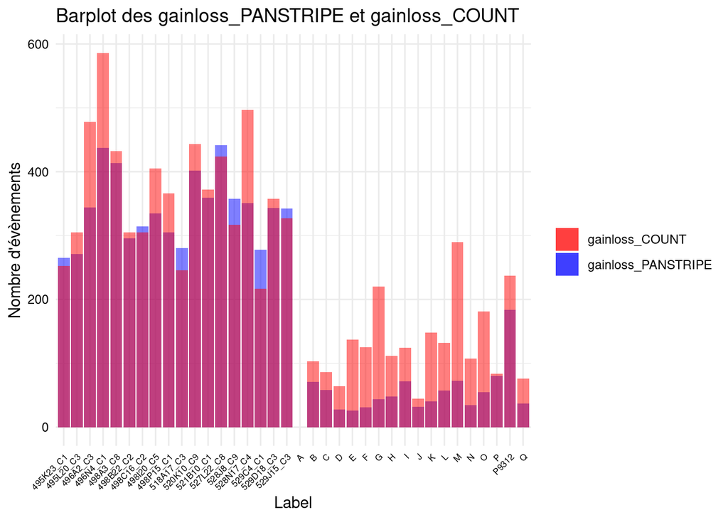

```r
#Barpot de la détection du nombres d'évènements en fonction de panstripe et count.
ggplot(merged_df, aes(x = Label)) +
  geom_bar(aes(y = gainloss_PANSTRIPE, fill = "gainloss_PANSTRIPE"),
           position = position_dodge(),
           stat = "identity",
           alpha = 0.5) +
  geom_bar(aes(y = gainloss_COUNT, fill = "gainloss_COUNT"),
           position = position_dodge(),
           stat = "identity",
           alpha = 0.5) +
  labs(title = "Barplot des gainloss_PANSTRIPE et gainloss_COUNT",
       x = "Label",
       y = "Nombre d'évènements",
       fill = "") +
  scale_fill_manual(values = c("gainloss_PANSTRIPE" = "blue", "gainloss_COUNT" = "red")) +
  theme_minimal()+theme(axis.text.x = element_text(size=6, angle = 45, vjust = 1, hjust=1, color="black"))+theme(axis.text.y = element_text(color="black"))
```

## Conclusion vis-à-vis des résultats obtenus

##### A partir du premier graph, il semblerait que le différentiel d’évènements calculé se situe essentiellement au niveau du calcul pour les branches qui ne sont pas tip (les branches non tip présentent les % les plus élevés)

##### Branche A = 0 car branche initiale de l’arbre (racine)

##### A partir du deuxième graph, il semblerait que count ait tendance à plus souvent/facilement trouver des évènements supplémentaires vis-à-vis de panstripe (beaucoup de barres oranges qui dépassent). Il semblerait aussi que panstripe trouve plus souvent des évènements en moins (barres bleus)

##### **Donc on a en moyenne un différence de calcul d’évènements entre Panstripe et Count d’environs 32%** (ce qui est quand même assez conséquent je suppose). La question était donc de savoir si on pouvait coupler les deux outils pour pouvoir identifier le nombre de gain/perte et identifier directement sur quels COGs cela se portait. Avec une différence de 32% (ce qui est donc conséquent), je suppose que c’est donc difficilement possible.

##### **CEPENDANT** en analysant les % de différences entre les TIP et NON TIP, on constate que la différence semble être moindre sur les TIP (environs 13% contre 55% pour les NON TIP). Donc pour les TIP la différence ne semble pas si énorme que ça en termes de différences dans la quantité d’évènements, après reste à voir si les évènements (gain/perte) le sont aussi ou non

##### **–> Comme on en avait parlé la dernière fois : essayer de voir si on peut trouver les gains/pertes dans panstripe (dans le code source) pour pouvoir comparer avec count ? Et voir si il est possible pour panstripe, comme pour count, d’identifier exactement quels COGs ça touche ?**